# Data Science i AI w bankowości - lista 1

Zuzanna Nogala

```python
import warnings
warnings.filterwarnings('ignore')

import pandas as pd
import seaborn as sns
import numpy as np
import matplotlib.pyplot as plt
import matplotlib.ticker as mtick
```

```python
sns.set_theme(style="whitegrid", context="notebook", palette="viridis", font_scale=0.9)
sns.set_style({'grid.linestyle': '--'})
plt.rcParams['figure.figsize'] = (8, 5)
```

## Wstęp

Celem raportu jest analiza danych miesięcznych sektora bankowego w okresie od 31 grudnia 2009 roku do 31 stycznia 2026 roku. Dane źródłowe pochodzą z zasobów Komisji Nadzoru Finansowego (KNF). W ujęciu rocznym szczegółowej analizie poddano:

- liczbę banków (z rozróżnieniem na komercyjne i spółdzielcze) oraz instytucji kredytowych;
- liczbę oddziałów, w tym podział na placówki krajowe i zagraniczne;
- poziom zatrudnienia w sektorze z uwzględnieniem podziału na liczbę pracowników w centrali, w kraju i zagranicy.

Źródło: [KNF - Dane miesięczne sektora bankowego](https://www.knf.gov.pl/?articleId=56224&p_id=18)

## 1. Zbiór danych

Wykorzystany materiał źródłowy z KNF składa się z dwóch odrębnych zbiorów danych. Pierwszy szereg obejmuje okres od grudnia 2009 do grudnia 2017, a drugi - od stycznia 2018 do stycznia 2026 roku. W ramach etapu przygotowawczego dokonano integracji obu zbiorów, ujednolicenia ich struktury oraz kontroli typów danych.

```python
data_to_2017 = pd.read_excel("KNF_bank_data.xlsx", sheet_name = "Data_12.2009-12.2017", index_col = 0).T
data_to_2017 = data_to_2017.reset_index(drop=False)
data_to_2017 = data_to_2017.rename(columns = {"index": "Data"})

data_to_2017.head(4)
```

|  | Data | liczba_banków_komercyjnych | liczba_banków_spółdzielczych | liczba_oddziałów_instytucji_kredytowych | liczba_oddziałów_kraj | liczba_oddziałów_za_granicą | liczba_zatrudnionych_suma | liczba_zatrudnionych_centrala | liczba_zatrudnionych_kraj | liczba_zatrudnionych_za_granicą |
| --- | --- | --- | --- | --- | --- | --- | --- | --- | --- | --- |
| 0 | 2009-12-31 | 49 | 576 | 18 | 6503 | 4 | 175249 | 68105 | 107009 | 135 |
| 1 | 2010-01-31 | 48 | 576 | 19 | 6833 | 4 | 173966 | 67757 | 106080 | 129 |
| 2 | 2010-02-28 | 48 | 576 | 20 | 6810 | 4 | 174258 | 68284 | 105841 | 133 |
| 3 | 2010-03-31 | 49 | 576 | 20 | 6889 | 4 | 175497 | 68872 | 106493 | 132 |

```python
data_to_2017.info()
```

```
<class 'pandas.DataFrame'>
RangeIndex: 97 entries, 0 to 96
Data columns (total 10 columns):
 #   Column                                   Non-Null Count  Dtype
---  ------                                   --------------  -----
 0   Data                                     97 non-null     datetime64[us]
 1   liczba_banków_komercyjnych               97 non-null     int64
 2   liczba_banków_spółdzielczych             97 non-null     int64
 3   liczba_oddziałów_instytucji_kredytowych  97 non-null     int64
 4   liczba_oddziałów_kraj                    97 non-null     int64
 5   liczba_oddziałów_za_granicą              97 non-null     int64
 6   liczba_zatrudnionych_suma                97 non-null     int64
 7   liczba_zatrudnionych_centrala            97 non-null     int64
 8   liczba_zatrudnionych_kraj                97 non-null     int64
 9   liczba_zatrudnionych_za_granicą          97 non-null     int64
dtypes: datetime64[us](1), int64(9)
memory usage: 7.7 KB
```

```python
data_from_2018 = pd.read_excel("KNF_bank_data.xlsx", sheet_name = "Data_01.2018-01.2026", index_col = 0).T
data_from_2018 = data_from_2018.reset_index(drop=False)
data_from_2018 = data_from_2018.rename(columns = {"index": "Data"})

data_from_2018.head(4)
```

|  | Data | liczba_banków_komercyjnych | liczba_oddziałów_instytucji_kredytowych | liczba_banków_spółdzielczych | liczba_oddziałów_kraj | liczba_oddziałów_za_granicą | liczba_zatrudnionych_suma | liczba_zatrudnionych_centrala | liczba_zatrudnionych_kraj | liczba_zatrudnionych_za_granicą |
| --- | --- | --- | --- | --- | --- | --- | --- | --- | --- | --- |
| 0 | 2018-01-31 | 35 | 29 | 552 | 6630 | 5 | 164317 | 74713 | 89235 | 369 |
| 1 | 2018-02-28 | 35 | 29 | 552 | 6612 | 5 | 164587 | 77626 | 86564 | 397 |
| 2 | 2018-03-31 | 35 | 29 | 552 | 6593 | 5 | 165015 | 78256 | 86354 | 405 |
| 3 | 2018-04-30 | 35 | 29 | 551 | 6579 | 5 | 164932 | 78636 | 85877 | 419 |

```python
data_from_2018.info()
```

```
<class 'pandas.DataFrame'>
RangeIndex: 97 entries, 0 to 96
Data columns (total 10 columns):
 #   Column                                   Non-Null Count  Dtype
---  ------                                   --------------  -----
 0   Data                                     97 non-null     datetime64[us]
 1   liczba_banków_komercyjnych               97 non-null     int64
 2   liczba_oddziałów_instytucji_kredytowych  97 non-null     int64
 3   liczba_banków_spółdzielczych             97 non-null     int64
 4   liczba_oddziałów_kraj                    97 non-null     int64
 5   liczba_oddziałów_za_granicą              97 non-null     int64
 6   liczba_zatrudnionych_suma                97 non-null     int64
 7   liczba_zatrudnionych_centrala            97 non-null     int64
 8   liczba_zatrudnionych_kraj                97 non-null     int64
 9   liczba_zatrudnionych_za_granicą          97 non-null     int64
dtypes: datetime64[us](1), int64(9)
memory usage: 7.7 KB
```

W obu zbiorach mamy dokładnie te same 10 kolumn. Ponadto kolumna "Data" ma format zmiennej czasowej (typ $\texttt{datetime64}$), natomiast pozostałe kolumny zawierają liczby naturalne (typ $\texttt{int64}$), co potwierdza poprawność struktury danych. Wobec tego możemy połączyć obie tabele i dodać kolumnę "Rok", która będzie potrzebna do przeprowadzenia dalszych analiz.

```python
data_full = pd.concat([data_to_2017, data_from_2018], axis = 0).reset_index(drop=True)
data_full['Rok'] = data_full['Data'].dt.year.astype(str)

pd.concat([data_full.head(2), data_full.tail(2)])
```

|  | Data | liczba_banków_komercyjnych | liczba_banków_spółdzielczych | liczba_oddziałów_instytucji_kredytowych | liczba_oddziałów_kraj | liczba_oddziałów_za_granicą | liczba_zatrudnionych_suma | liczba_zatrudnionych_centrala | liczba_zatrudnionych_kraj | liczba_zatrudnionych_za_granicą | Rok |
| --- | --- | --- | --- | --- | --- | --- | --- | --- | --- | --- | --- |
| 0 | 2009-12-31 | 49 | 576 | 18 | 6503 | 4 | 175249 | 68105 | 107009 | 135 | 2009 |
| 1 | 2010-01-31 | 48 | 576 | 19 | 6833 | 4 | 173966 | 67757 | 106080 | 129 | 2010 |
| 192 | 2025-12-31 | 30 | 488 | 35 | 4861 | 6 | 149273 | 94472 | 54352 | 449 | 2025 |
| 193 | 2026-01-31 | 30 | 488 | 35 | 4860 | 6 | 149645 | 95119 | 54079 | 447 | 2026 |

```python
data_to_2017, data_from_2018 = None, None

data_full.info()
```

```
<class 'pandas.DataFrame'>
RangeIndex: 194 entries, 0 to 193
Data columns (total 11 columns):
 #   Column                                   Non-Null Count  Dtype
---  ------                                   --------------  -----
 0   Data                                     194 non-null    datetime64[us]
 1   liczba_banków_komercyjnych               194 non-null    int64
 2   liczba_banków_spółdzielczych             194 non-null    int64
 3   liczba_oddziałów_instytucji_kredytowych  194 non-null    int64
 4   liczba_oddziałów_kraj                    194 non-null    int64
 5   liczba_oddziałów_za_granicą              194 non-null    int64
 6   liczba_zatrudnionych_suma                194 non-null    int64
 7   liczba_zatrudnionych_centrala            194 non-null    int64
 8   liczba_zatrudnionych_kraj                194 non-null    int64
 9   liczba_zatrudnionych_za_granicą          194 non-null    int64
 10  Rok                                      194 non-null    str
dtypes: datetime64[us](1), int64(9), str(1)
memory usage: 16.8 KB
```

## 2. Jakość danych

```python
data_full.drop(columns = ['Rok']).describe()
```

|  | Data | liczba_banków_komercyjnych | liczba_banków_spółdzielczych | liczba_oddziałów_instytucji_kredytowych | liczba_oddziałów_kraj | liczba_oddziałów_za_granicą | liczba_zatrudnionych_suma | liczba_zatrudnionych_centrala | liczba_zatrudnionych_kraj | liczba_zatrudnionych_za_granicą |
| --- | --- | --- | --- | --- | --- | --- | --- | --- | --- | --- |
| count | 194 | 194.000000 | 194.000000 | 194.000000 | 194.000000 | 194.000000 | 194.000000 | 194.000000 | 194.000000 | 194.000000 |
| mean | 2018-01-14 09:46:23.505154 | 36.128866 | 541.108247 | 29.335052 | 6298.984536 | 6.092784 | 161751.056701 | 78255.479381 | 83129.365979 | 366.211340 |
| min | 2009-12-31 00:00:00 | 29.000000 | 488.000000 | 18.000000 | 4857.000000 | 3.000000 | 142463.000000 | 67757.000000 | 54079.000000 | 124.000000 |
| 25% | 2014-01-07 18:00:00 | 30.000000 | 505.000000 | 27.000000 | 5202.000000 | 4.000000 | 146951.750000 | 72386.250000 | 62246.250000 | 224.250000 |
| 50% | 2018-01-15 12:00:00 | 35.000000 | 552.500000 | 29.000000 | 6621.000000 | 5.000000 | 164890.000000 | 77236.500000 | 87297.000000 | 358.000000 |
| 75% | 2022-01-23 06:00:00 | 40.750000 | 570.750000 | 34.000000 | 7232.750000 | 6.000000 | 173796.000000 | 80622.750000 | 101214.000000 | 531.500000 |
| max | 2026-01-31 00:00:00 | 49.000000 | 576.000000 | 37.000000 | 7530.000000 | 197.000000 | 178101.000000 | 95119.000000 | 107012.000000 | 690.000000 |
| std | NaN | 6.925128 | 31.973169 | 4.978306 | 955.172276 | 13.813399 | 12825.909072 | 6523.424007 | 18780.163314 | 164.641302 |

Dane zawierają 194 obserwacje. Wstępna analiza statystyk opisowych wskazuje, że dla większości zmiennych średnia i mediana przyjmują zbliżone wartości, co sugeruje rozkłady bliskie symetrycznym. Natomiast w przypadku liczby oddziałów w kraju oraz liczby banków spółdzielczych widoczne są pewne rozbieżności między tymi miarami, co może wskazywać na umiarkowaną skośność. Warto również odnotować znaczną zmienność w poziomie zatrudnienia.

W kolejnym kroku przeanalizujemy wykresy dla poszczególnych zmiennych, aby zidentyfikować ewentualne nieścisłości w danych źródłowych.

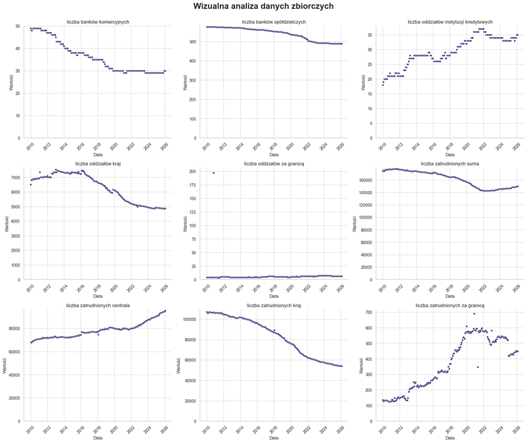

```python
cols_to_plot = data_full.columns.drop(['Data', 'Rok'])

fig, axes = plt.subplots(3, 3, figsize=(18, 15))
axes = axes.flatten()
fig.suptitle("Wizualna analiza danych zbiorczych", fontsize = 20, fontweight='bold', y=1.00)

for i, col in enumerate(cols_to_plot):
    sns.scatterplot(data=data_full, x='Data', y=col, ax=axes[i], s=20)

    axes[i].set_title(col.replace("_", " "), fontsize = 12)
    axes[i].tick_params(axis='x', rotation=45)
    axes[i].set_ylabel(f"Wartość")
    axes[i].set_ylim(bottom = 0)

    sns.despine(ax=axes[i])

plt.tight_layout()
plt.show()
```

Większość zmiennych nie wykazuje nietypowego zachowania. Wyjątkiem są dwie zmienne: $\textit{liczba oddziałów za granicą}$ i $\textit{liczba zatrudnionych za granicą}$, gdzie w ich przypadku zidentyfikowano pewne niespójności. Na poniższym wykresie zaprezentowano przebieg tych zmiennych wraz z wyróżnionymi wartościami budzącymi wątpliwości.

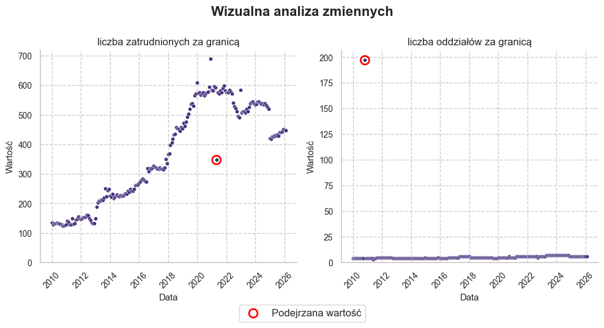

```python
cols_to_plot = ['liczba_zatrudnionych_za_granicą', 'liczba_oddziałów_za_granicą']
outliers_dates = ['2021-04-30', '2010-10-31']

# Wykres
fig, axes = plt.subplots(1, 2, figsize=(10, 5))
axes = axes.flatten()
fig.suptitle("Wizualna analiza zmiennych", fontsize = 16, fontweight='bold', y=1.00)

for i, col in enumerate(cols_to_plot):
    sns.scatterplot(data=data_full, x='Data', y=col, ax=axes[i], s=20)

    axes[i].set_title(col.replace("_", " "), fontsize = 12)
    axes[i].tick_params(axis='x', rotation=45)
    axes[i].set_ylabel(f"Wartość")
    axes[i].set_ylim(bottom = 0)

    outlier_data = data_full.loc[data_full.Data == outliers_dates[i]]

    axes[i].scatter(x=outlier_data['Data'], y=outlier_data[col],
                    edgecolor='red', facecolor='none', s=100, linewidth=2,
                    label='Podejrzana wartość'
    )

    sns.despine(ax=axes[i])

# Poprawa legendy
handles, labels = axes[0].get_legend_handles_labels()

fig.legend(handles, labels,
           loc='lower center', bbox_to_anchor=(0.5, -0.05), ncol=2,
           frameon=True, fontsize=12
)

plt.tight_layout()
plt.show()
```

Wyżej pokazane zmienne zostały szczegółowo przeanalizowe w następnych podrozdziałach.

## 2.1 Analiza liczby zatrudniania za granicą

```python
data_full.loc[data_full.Rok == '2021', ['Data', 'liczba_zatrudnionych_za_granicą']]
```

|  | Data | liczba_zatrudnionych_za_granicą |
| --- | --- | --- |
| 133 | 2021-01-31 | 582 |
| 134 | 2021-02-28 | 596 |
| 135 | 2021-03-31 | 593 |
| 136 | 2021-04-30 | 347 |
| 137 | 2021-05-31 | 576 |
| 138 | 2021-06-30 | 571 |
| 139 | 2021-07-31 | 582 |
| 140 | 2021-08-31 | 576 |
| 141 | 2021-09-30 | 591 |
| 142 | 2021-10-31 | 598 |
| 143 | 2021-11-30 | 581 |
| 144 | 2021-12-31 | 576 |

Dla zmiennej opisującej poziom zatrudnienia nietypowa jest obserwacja z roku 2021, dokładniej z 30 kwietnia. W tym miesiącu zanotowano istotnie mniejsze zatrudnienie (około 350 pracowników) niż w latach 2020-2022, gdzie obserwowano średnio około 540-580 pracowników w miesiącu.

```python
indx = (data_full.Rok >= '2020') & (data_full.Rok <= '2022')

data_full.loc[indx].groupby('Rok', as_index=False).agg(średnia_zatrudniania_za_granica = ('liczba_zatrudnionych_za_granicą', 'mean'))
```

|  | Rok | średnia_zatrudniania_za_granica |
| --- | --- | --- |
| 0 | 2020 | 585.250000 |
| 1 | 2021 | 564.083333 |
| 2 | 2022 | 546.083333 |

Natomiast, należy zaznaczyć, że analizowany okres pokrywa się z pandemią COVID-19 i stagnacją na rynku pracy w sektorze bankowowym. Zatem scenariusz tak niskiego zatrudnienia w tych warunkach jest prawdopodobny. Dodatkowo, udział zatrudnienia zagranicznego wynosi jedynie 0,24% w całym sektorze, więc jego wpływ na całkowity poziom zatrudnienia jest znikomy. Dlatego uznano tę wartość za realistyczną i pozostawiono ją bez zmian.

```python
data_full.loc[data_full.Rok == '2010', ['Data', 'liczba_oddziałów_za_granicą']]
```

|  | Data | liczba_oddziałów_za_granicą |
| --- | --- | --- |
| 1 | 2010-01-31 | 4 |
| 2 | 2010-02-28 | 4 |
| 3 | 2010-03-31 | 4 |
| 4 | 2010-04-30 | 4 |
| 5 | 2010-05-31 | 4 |
| 6 | 2010-06-30 | 4 |
| 7 | 2010-07-31 | 4 |
| 8 | 2010-08-31 | 4 |
| 9 | 2010-09-30 | 4 |
| 10 | 2010-10-31 | 197 |
| 11 | 2010-11-30 | 4 |
| 12 | 2010-12-31 | 4 |

```python
data_full.loc[data_full.Data == '2010-10-31', 'liczba_oddziałów_za_granicą'] = 4
data_full.loc[data_full.Data == '2010-10-31']
```

|  | Data | liczba_banków_komercyjnych | liczba_banków_spółdzielczych | liczba_oddziałów_instytucji_kredytowych | liczba_oddziałów_kraj | liczba_oddziałów_za_granicą | liczba_zatrudnionych_suma | liczba_zatrudnionych_centrala | liczba_zatrudnionych_kraj | liczba_zatrudnionych_za_granicą | Rok |
| --- | --- | --- | --- | --- | --- | --- | --- | --- | --- | --- | --- |
| 10 | 2010-10-31 | 49 | 576 | 22 | 6920 | 4 | 177151 | 70607 | 106420 | 124 | 2010 |

## 3. Analiza poszczególnych zmiennych w ujęciu rocznym

Zgodnie z zapowiedzią we wstępie, analizie w ujęciu rocznym poddano: liczbę banków i instytucji kredytowych, liczbę oddziałów oraz poziom zatrudnienia.

W tym celu dane źródłowe zgrupowano według lat, a następnie na ich podstawie wyliczono wartości średnie. Należy zaznaczyć, że dla lat 2009 oraz 2026 dostępna jest tylko jedna obserwacja (odpowiednio z grudnia i stycznia), zatem średnia roczna dla tych okresów jest tożsama z wartością z danego miesiąca. Zdecydowano się jednak na pozostawienie tych punktów danych, aby zachować ciągłość i precyzyjniej zarysować trend występujący w analizowanych zmiennych.

```python
data_year_grouped = data_full.drop(columns = ['Data']).groupby('Rok', as_index = False).agg(['count', 'mean'])
data_year_grouped
```

|  | Rok | liczba_banków_komercyjnych count | liczba_banków_komercyjnych mean | liczba_banków_spółdzielczych count | liczba_banków_spółdzielczych mean | liczba_oddziałów_instytucji_kredytowych count | liczba_oddziałów_instytucji_kredytowych mean | liczba_oddziałów_kraj count | liczba_oddziałów_kraj mean | liczba_oddziałów_za_granicą count | liczba_oddziałów_za_granicą mean | liczba_zatrudnionych_suma count | liczba_zatrudnionych_suma mean | liczba_zatrudnionych_centrala count | liczba_zatrudnionych_centrala mean | liczba_zatrudnionych_kraj count | liczba_zatrudnionych_kraj mean | liczba_zatrudnionych_za_granicą count | liczba_zatrudnionych_za_granicą mean |
| --- | --- | --- | --- | --- | --- | --- | --- | --- | --- | --- | --- | --- | --- | --- | --- | --- | --- | --- | --- |
| 0 | 2009 | 1 | 49.000000 | 1 | 576.000000 | 1 | 18.000000 | 1 | 6503.000000 | 1 | 4.000000 | 1 | 175249.000000 | 1 | 68105.000000 | 1 | 107009.000000 | 1 | 135.000000 |
| 1 | 2010 | 12 | 48.833333 | 12 | 576.000000 | 12 | 20.500000 | 12 | 6885.916667 | 12 | 4.000000 | 12 | 176301.333333 | 12 | 69759.500000 | 12 | 106412.166667 | 12 | 129.666667 |
| 2 | 2011 | 12 | 48.000000 | 12 | 574.750000 | 12 | 21.333333 | 12 | 7052.166667 | 12 | 4.333333 | 12 | 177476.583333 | 12 | 71573.666667 | 12 | 105762.166667 | 12 | 140.750000 |
| 3 | 2012 | 12 | 46.333333 | 12 | 572.916667 | 12 | 22.666667 | 12 | 7201.750000 | 12 | 4.666667 | 12 | 175953.666667 | 12 | 72342.166667 | 12 | 103463.500000 | 12 | 148.000000 |
| 4 | 2013 | 12 | 42.333333 | 12 | 571.916667 | 12 | 27.333333 | 12 | 7392.166667 | 12 | 4.000000 | 12 | 174256.416667 | 12 | 72417.416667 | 12 | 101618.500000 | 12 | 220.500000 |
| 5 | 2014 | 12 | 39.166667 | 12 | 567.250000 | 12 | 28.000000 | 12 | 7307.166667 | 12 | 4.083333 | 12 | 173042.083333 | 12 | 72297.416667 | 12 | 100519.416667 | 12 | 225.250000 |
| 6 | 2015 | 12 | 37.833333 | 12 | 562.500000 | 12 | 28.000000 | 12 | 7307.666667 | 12 | 4.166667 | 12 | 171314.000000 | 12 | 73557.916667 | 12 | 97507.333333 | 12 | 248.750000 |
| 7 | 2016 | 12 | 37.166667 | 12 | 559.666667 | 12 | 26.166667 | 12 | 7253.000000 | 12 | 4.500000 | 12 | 170295.500000 | 12 | 76422.666667 | 12 | 93575.166667 | 12 | 297.666667 |
| 8 | 2017 | 12 | 35.333333 | 12 | 555.500000 | 12 | 27.833333 | 12 | 6809.750000 | 12 | 5.750000 | 12 | 166378.333333 | 12 | 76984.916667 | 12 | 89067.083333 | 12 | 326.333333 |
| 9 | 2018 | 12 | 34.166667 | 12 | 550.583333 | 12 | 29.416667 | 12 | 6495.083333 | 12 | 5.000000 | 12 | 164187.416667 | 12 | 78581.416667 | 12 | 85174.666667 | 12 | 431.333333 |
| 10 | 2019 | 12 | 31.000000 | 12 | 543.250000 | 12 | 31.916667 | 12 | 6083.833333 | 12 | 4.666667 | 12 | 159584.333333 | 12 | 80264.666667 | 12 | 78796.750000 | 12 | 522.916667 |
| 11 | 2020 | 12 | 30.000000 | 12 | 533.166667 | 12 | 34.000000 | 12 | 5845.416667 | 12 | 5.083333 | 12 | 152890.583333 | 12 | 79410.666667 | 12 | 72894.666667 | 12 | 585.250000 |
| 12 | 2021 | 12 | 29.583333 | 12 | 521.333333 | 12 | 36.583333 | 12 | 5346.750000 | 12 | 5.833333 | 12 | 145148.916667 | 12 | 79619.500000 | 12 | 64965.333333 | 12 | 564.083333 |
| 13 | 2022 | 12 | 30.000000 | 12 | 499.416667 | 12 | 35.083333 | 12 | 5107.083333 | 12 | 5.916667 | 12 | 142793.250000 | 12 | 81196.250000 | 12 | 61050.916667 | 12 | 546.083333 |
| 14 | 2023 | 12 | 29.583333 | 12 | 492.250000 | 12 | 34.000000 | 12 | 5007.583333 | 12 | 6.750000 | 12 | 144180.166667 | 12 | 85187.333333 | 12 | 58468.416667 | 12 | 524.416667 |
| 15 | 2024 | 12 | 29.000000 | 12 | 490.250000 | 12 | 33.250000 | 12 | 4903.416667 | 12 | 6.833333 | 12 | 146034.500000 | 12 | 89002.583333 | 12 | 56505.916667 | 12 | 526.000000 |
| 16 | 2025 | 12 | 29.166667 | 12 | 488.500000 | 12 | 33.750000 | 12 | 4887.916667 | 12 | 6.000000 | 12 | 148063.833333 | 12 | 92910.166667 | 12 | 54718.750000 | 12 | 434.916667 |
| 17 | 2026 | 1 | 30.000000 | 1 | 488.000000 | 1 | 35.000000 | 1 | 4860.000000 | 1 | 6.000000 | 1 | 149645.000000 | 1 | 95119.000000 | 1 | 54079.000000 | 1 | 447.000000 |

## 3.1 Liczba banków i oddziałów kredytowych w ujęciu rocznym

W pierwszej kolejności poddano analizie średnią liczbę banków oraz instytucji kredytowych. Zbadano, jak na przestrzeni lat zmieniał się udział banków komercyjnych, spółdzielczych oraz instytucji kredytowych w ogólnej strukturze sektora bankowego. Wyniki zostały przedstawione na wykresie poniżej.

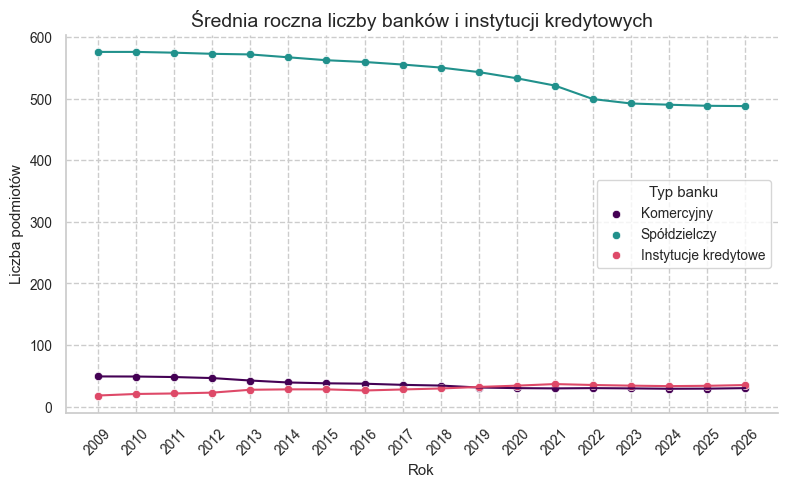

```python
# Parametry
color_dic = {'liczba_banków_komercyjnych':'#440154',
            'liczba_banków_spółdzielczych': "#21918c",
            'liczba_oddziałów_instytucji_kredytowych': '#de4968'}

label_dic = {'liczba_banków_komercyjnych': 'Komercyjny',
             'liczba_banków_spółdzielczych': 'Spółdzielczy',
             'liczba_oddziałów_instytucji_kredytowych': 'Instytucje kredytowe'}

# Wykres
for col in label_dic.keys():
    sns.scatterplot(data_year_grouped, x = 'Rok', y = (col, 'mean'), label = label_dic[col], color = color_dic[col])
    sns.lineplot(data_year_grouped, x = 'Rok', y = (col, 'mean'), color = color_dic[col])

plt.title('Średnia roczna liczby banków i instytucji kredytowych', fontsize = 14)
sns.despine()
plt.legend()
plt.ylabel("Liczba podmiotów")
plt.tick_params(axis='x', rotation=45)
plt.legend(loc='center right', title = 'Typ banku')
plt.tight_layout()
plt.show()
```

## 3.2 Liczba oddziałów

W tym podrozdziale poddano analizie średnią liczbę oddziałów. Zbadano, jak na przestrzeni lat zmieniał się udział oddziałów za granicą oraz w kraju w ogólnej strukturze sektora bankowego. Wyniki zostały przedstawione na wykresie poniżej.

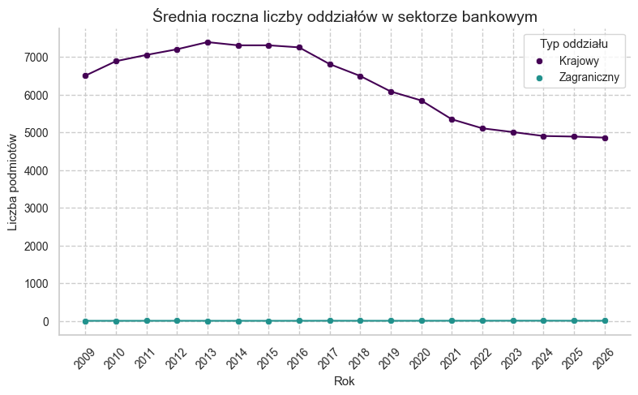

```python
# Parametry estetyczne
color_dic = {'liczba_oddziałów_kraj':'#440154',
            'liczba_oddziałów_za_granicą': "#21918c"}

label_dic = {'liczba_oddziałów_kraj': 'Krajowy',
             'liczba_oddziałów_za_granicą': 'Zagraniczny'}

# Wykres
for col in label_dic.keys():
    sns.scatterplot(data_year_grouped, x = 'Rok', y = (col, 'mean'), label = label_dic[col], color = color_dic[col])
    sns.lineplot(data_year_grouped, x = 'Rok', y = (col, 'mean'), color = color_dic[col])

plt.title('Średnia roczna liczby oddziałów w sektorze bankowym', fontsize = 14)
sns.despine()
plt.legend()
plt.ylabel("Liczba podmiotów")
plt.tick_params(axis='x', rotation=45)
plt.legend(loc='upper right', title = 'Typ oddziału')
plt.tight_layout()
plt.show()
```

Zupełnie inną dynamikę odnotowano w przypadku oddziałów krajowych. W latach 2009–2013 trwał okres intensywnego rozwoju sieci sprzedaży, co skutkowało wzrostem liczby placówek. Następnie, w latach 2013–2016, sytuacja ustabilizowała się na poziomie około 7 300 jednostek. Przełom nastąpił po 2016 roku, kiedy rozpoczął się gwałtowny trend spadkowy, trwający do 2022 roku. Ten gwałtowny spadek mozna wyjasnić rosnącą popularnością bankowości internetowej, która zmieniła nawyki klientów. W tym czasie banki zaczęły zamykać nierentowne placówki, stawiając na obsługę zdalną. Obecnie sieć sprzedaży ponownie wkroczyła w fazę stabilizacji, osiągając poziom około 5000 placówek.

## 3.3 Liczba zatrudnionych

Na koniec przeanalizowano średni poziom zatrudnionych. Zbadano, jak na przestrzeni lat zmieniała się liczba pracowników w kraju, w centrali i za granicą w ogólnej strukturze sektora bankowego. Wyniki zostały przedstawione na wykresach poniżej.

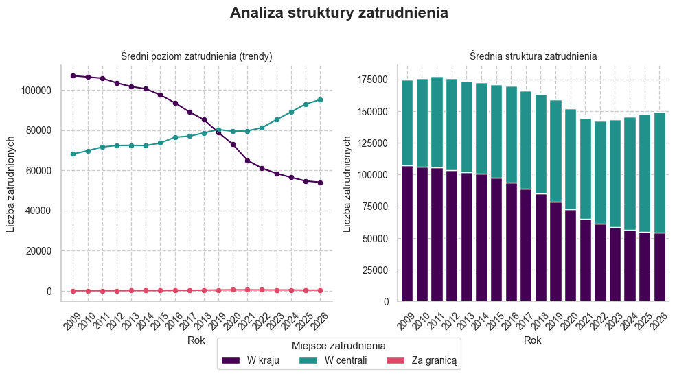

```python
# Parametry estetyczne
color_dic = {'liczba_zatrudnionych_kraj':'#440154',
            'liczba_zatrudnionych_centrala': "#21918c",
            'liczba_zatrudnionych_za_granicą': '#de4968'}

label_dic = {'liczba_zatrudnionych_kraj': 'W kraju',
             'liczba_zatrudnionych_centrala': 'W centrali',
             'liczba_zatrudnionych_za_granicą': 'Za granicą'}


fig, axes = plt.subplots(1, 2, figsize=(10, 5))
fig.suptitle("Analiza struktury zatrudnienia", fontsize=16, fontweight='bold', y=1.02)

# Wykres liniowy
for col in label_dic.keys():
    sns.scatterplot(data=data_year_grouped, x='Rok', y=(col, 'mean'), ax=axes[0], color = color_dic[col])
    sns.lineplot(data=data_year_grouped, x='Rok', y=(col, 'mean'),ax=axes[0], color = color_dic[col])

axes[0].set_title('Średni poziom zatrudnienia (trendy)', fontsize = 10)
axes[0].set_ylabel("Liczba zatrudnionych")
axes[0].set_xlabel("Rok")
axes[0].tick_params(axis='x', rotation=45)

# Wykres słupkowy
plot_df = data_year_grouped[[(col, 'mean') for col in label_dic.keys()]]
plot_df.columns = [label_dic[col] for col in label_dic.keys()]
plot_df.index = data_year_grouped['Rok']
plot_df.plot(kind='bar', stacked=True, ax=axes[1], width=0.8, legend = False, color=color_dic.values())


axes[1].set_title('Średnia struktura zatrudnienia', fontsize = 10)
axes[1].set_ylabel("Liczba zatrudnienych")
axes[1].set_xlabel("Rok")
axes[1].tick_params(axis='x', rotation=45)

# Poprawa legendy
handles, labels = axes[1].get_legend_handles_labels()

fig.legend(handles, labels,
           loc='lower center',
           bbox_to_anchor=(0.5, -0.05),
           ncol=3,
           title='Miejsce zatrudnienia',
           frameon=True)

sns.despine()
plt.tight_layout()
plt.show()
```

Zupełnie odmienną tendencję wykazuje zatrudnienie w kraju oraz w jednostkach centralnych. Pod koniec 2009 roku dominowało zatrudnienie w sieci krajowej, które jednak od tego czasu znajduje się w stałym trendzie spadkowym. Z kolei liczba etatów w centralach, wynosząca na początku okresu ok. 70 000, systematycznie rosła. Zmiana ta jest bezpośrednim skutkiem transformacji cyfrowej. Postępująca automatyzacja procesów oraz rosnąca popularność bankowości internetowej i mobilnej pozwoliły na redukcję personelu poza centralą. Ponadto, z tradycyjnych instytucji opartych na obecności w firmie, banki stały się organizacjami technologicznymi, które intensywnie rozbudowywały zespoły IT, analityczne oraz cyberbezpieczeństwa skupione w centrach decyzyjnych.

Trend wzrostowy w centralach trwał do 2019 roku, kiedy to w obliczu pandemii nastąpiła faza stagnacji. Po 2022 roku, wraz ze stabilizacją sytuacji rynkowej, odnotowano ponowne odbicie, które trwa do dziś. Wynika ono przede wszystkim z trwałego upowszechnienia modelu pracy zdalnej i hybrydowej. Możliwość świadczenia pracy spoza głównej siedziby banku pozwoliła na zwiększenie potencjału kadrowego i rekrutację specjalistów z całego kraju bez konieczności fizycznej rozbudowy powierzchni biurowej.

## Wnioski

Analiza sektora bankowego w latach 2009–2026 wskazuje na transformację strukturalną, technologiczną i kadrową.

Podsumowując, sektor bankowy w Polsce wkracza w fazę stabilizacji po okresie intensywnej optymalizacji i epidemii COVID-19. Kluczowymi filarami obecnej kondycji branży są automatyzacja procesów, silne centra decyzyjne oraz model pracy hybrydowej. Redukcja tradycyjnej sieci sprzedaży nie osłabiła sektora, lecz pozwoliła na jego technologiczną modernizację i lepsze dopasowanie do wymogów cyfrowej gospodarki.